# Time Series Analysis - Newly Registered Vehicles in Poland

Piotr Wieczorek

2023-06-23

## **1 Goal of this project**

#### The goal of the analysis is to make a forecast of the time series presenting data on number of vehicles registered in Poland for the first time (from 01.01.2012 to 01.04.2023) for the period **01.05.2023 - 01.04.2025**

## **2 Libraries**

```r
library(dplyr)
library(tidyverse)
library(tseries)
library(GGally)
library(forecast)
library(readxl)
library(lubridate)
library(scales)
library(patchwork)
library(kableExtra)
library(ggpubr)
library(png)
library(jpeg)
```

## **3 Reading and preparing the data**

```r
df <- read_excel("time_series_vehicles_data.xlsx")
```

```r
df$t <- lubridate::ymd(df$t)
class(df$t)
```

```
## [1] "Date"
```

```r
colnames(df)[2] <- "Newly_registered_vehicles"
```

```r
head(df)
```

```
## # A tibble: 6 × 2
##   t          Newly_registered_vehicles
##   <date>                         <dbl>
## 1 2012-01-01                     86947
## 2 2012-02-01                     88000
## 3 2012-03-01                    128124
## 4 2012-04-01                    125540
## 5 2012-05-01                    126435
## 6 2012-06-01                    116360
```

### **3.1 Data correction - the beginning of the COVID-19 pandemic**

#### As the beginning of the COVID-19 pandemic (March, April 2020) led to an unpredictable standstill, the values of newly registered vehicles in Poland for these two periods have been converted to the February 2020 value.

```r
df[c(98:100),1:2]
```

```
## # A tibble: 3 × 2
##   t          Newly_registered_vehicles
##   <date>                         <dbl>
## 1 2020-02-01                    149826
## 2 2020-03-01                    106009
## 3 2020-04-01                     67159
```

```r
df[c(99,100),2] <- df[98,2]
```

```r
df[98:100,1:2]
```

```
## # A tibble: 3 × 2
##   t          Newly_registered_vehicles
##   <date>                         <dbl>
## 1 2020-02-01                    149826
## 2 2020-03-01                    149826
## 3 2020-04-01                    149826
```

```r
df_ts <- ts(df$Newly_registered_vehicles,start = 2012,frequency = 12)
```

```r
df_ts
```

```
##         Jan    Feb    Mar    Apr    May    Jun    Jul    Aug    Sep    Oct
## 2012  86947  88000 128124 125540 126435 116360 124207 115023 103011 115685
## 2013  93707  94114 114761 127906 127923 136334 133480 112551 111434 125225
## 2014 104239 113636 138199 136844 125163 124690 137489 114159 122762 130778
## 2015 110062 113891 148740 145327 136829 142871 153387 122634 134159 131480
## 2016 121232 137250 160116 162463 153889 165541 150717 149434 152903 142997
## 2017 123077 130683 176063 151183 159897 161115 155418 150517 148278 157866
## 2018 147214 141134 176079 186332 168514 169733 172337 178448 139693 169070
## 2019 145532 150682 180977 185272 177250 161535 183705 165607 146196 171689
## 2020 147655 149826 149826 149826 111529 149599 173569 144337 160049 152448
## 2021 122902 140608 188058 113409 129964 173944 163018 147111 149352 143568
## 2022 116785 129092 154626 142196 147888 148873 135515 131251 137006 126879
## 2023 123610 127002 165882 137139
##         Nov    Dec
## 2012 101767  83377
## 2013 101333 100784
## 2014 101180 108186
## 2015 119082 126090
## 2016 148809 176698
## 2017 137422 138258
## 2018 149854 139479
## 2019 145629 154115
## 2020 133626 160577
## 2021 137252 141855
## 2022 126389 121959
## 2023
```

#### Setting up the theme

```r
th <- theme(
        axis.text.x = element_text(size=12),
        axis.text.y = element_text(size=12),
        title = element_text(size=16),
        axis.title.x = element_text(size=12),
        axis.title.y = element_text(size=12))
```

### **3.2 Base plot - newly registered vehicles in Poland from 01.01.2012 to 01.04.2023**

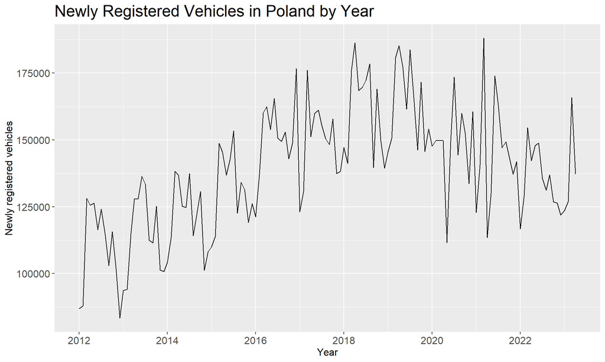

```r
autoplot(df_ts,main = "Newly Registered Vehicles in Poland by Year",xlab = "Year",ylab="Newly registered vehicles") + th
```

## **4 Other datasets**

#### Other datasets were also included in order to examine whether or not there is a correlation between these variables and the number of newly registered vehicles in Poland

### **4.1 Inflation in the tranport sector data (regarding Poland)**

```r
df2 <- read_excel("transport_inflation.xlsx")
```

```r
head(df2)
```

```
## # A tibble: 6 × 2
##   t                   transport_inflation
##   <dttm>              <chr>
## 1 2012-01-01 00:00:00 109.2
## 2 2012-02-01 00:00:00 110.3
## 3 2012-03-01 00:00:00 109.3
## 4 2012-04-01 00:00:00 108.7
## 5 2012-05-01 00:00:00 108.1
## 6 2012-06-01 00:00:00 108.2
```

```r
df2 <- df2 %>%
mutate(transport_inflation = as.numeric(transport_inflation))
```

```r
df2$t <- lubridate::ymd(df2$t)
class(df2$t)
```

```
## [1] "Date"
```

```r
df2_ts <- ts(df2$transport_inflation,start = 2012,frequency = 12)
```

```r
df2_ts
```

```
##        Jan   Feb   Mar   Apr   May   Jun   Jul   Aug   Sep   Oct   Nov   Dec
## 2012 109.2 110.3 109.3 108.7 108.1 108.2 106.8 106.5 108.0 106.0 103.1 101.1
## 2013  99.2  99.4  99.5  97.8  95.8  96.5  98.8  98.6  98.6  97.7  97.7  99.1
## 2014  98.5  98.2  97.3  97.9  99.9  99.4  99.0  98.5  96.8  97.0  96.3  93.5
## 2015  89.8  88.4  90.1  90.9  92.0  92.7  93.0  91.7  90.0  89.6  91.8  93.2
## 2016  93.6  92.7  91.6  92.0  93.2  94.0  92.9  93.1  97.5 100.3  99.8 104.3
## 2017 108.7 111.2 109.4 108.7 104.2 100.0  99.2 101.8 101.6 100.4 102.3  99.2
## 2018  98.8  98.0  98.1  99.9 104.8 108.6 110.1 108.5 107.0 107.5 106.1 104.0
## 2019 101.9 102.5 103.5 104.8 101.7 101.4 100.3  99.8  98.3  97.0  96.6 100.5
## 2020 102.1 101.4  98.6  90.1  87.2  89.6  91.5  92.9  95.1  95.4  95.6  94.3
## 2021  96.0  98.4 105.4 116.2 119.5 116.5 118.5 117.8 118.5 122.1 124.1 122.7
## 2022 117.2 109.9 124.1 121.1 125.8 133.4 127.7 119.5 116.4 117.3 114.4 113.3
## 2023 116.5 123.7 103.9 104.6
```

### **4.2 Salary data (regarding Poland)**

```r
df3 <- read_excel("average_real_salary.xlsx")
```

```r
head(df3)
```

```
## # A tibble: 6 × 2
##   t                   Average_monthly_real_gross_salary_business_sector
##   <dttm>              <chr>
## 1 2012-01-01 00:00:00 103.9
## 2 2012-02-01 00:00:00 100.1
## 3 2012-03-01 00:00:00 100.0
## 4 2012-04-01 00:00:00 99.5
## 5 2012-05-01 00:00:00 100.3
## 6 2012-06-01 00:00:00 100.2
```

```r
df3 <- df3 %>%
mutate(Average_monthly_real_gross_salary_business_sector = as.numeric(Average_monthly_real_gross_salary_business_sector))
```

```r
df3$t <- lubridate::ymd(df3$t)
class(df3$t)
```

```
## [1] "Date"
```

```r
head(df3)
```

```
## # A tibble: 6 × 2
##   t          Average_monthly_real_gross_salary_business_sector
##   <date>                                                 <dbl>
## 1 2012-01-01                                             104.
## 2 2012-02-01                                             100.
## 3 2012-03-01                                             100
## 4 2012-04-01                                              99.5
## 5 2012-05-01                                             100.
## 6 2012-06-01                                             100.
```

```r
df3_ts <- ts(df3$Average_monthly_real_gross_salary_business_sector,start = 2012,frequency = 12)
```

```r
df3_ts
```

```
##        Jan   Feb   Mar   Apr   May   Jun   Jul   Aug   Sep   Oct   Nov   Dec
## 2012 103.9 100.1 100.0  99.5 100.3 100.2  98.7  99.0  98.0  99.5 100.0 100.0
## 2013  98.7 102.8 100.6 102.2 101.8 101.1 102.4 100.9 102.6 102.3 102.5 102.1
## 2014 103.0 103.3 104.2 103.5 104.6 103.2 103.6 103.7 103.7 104.3 103.2 104.7
## 2015 105.2 105.0 106.6 104.9 104.1 103.4 104.1 104.1 105.2 104.2 104.7 103.8
## 2016 104.9 104.8 104.3 105.9 105.2 106.1 105.9 105.7 104.4 103.7 104.0 101.8
## 2017 102.6 101.8 103.1 102.1 103.4 104.5 103.2 104.8 103.9 105.4 104.1 105.3
## 2018 105.5 105.5 105.4 106.2 105.3 105.5 105.1 104.6 104.7 105.7 106.3 104.9
## 2019 106.6 106.2 103.9 104.8 105.3 102.6 104.5 104.0 104.0 103.4 102.7 102.8
## 2020 102.8 103.0 101.8  98.7  98.5 100.6 100.9 101.3 102.4 101.7 101.9 104.2
## 2021 102.2 102.1 104.7 105.2 105.0 105.1 103.4 103.8 102.6 101.4 101.9 102.4
## 2022 100.2 103.0 101.4 101.7  99.7  97.9 100.3  97.3  98.0  96.2  97.3  94.8
## 2023  97.5  96.1  97.2  97.9
```

### **4.3 Unemployment data (regarding Poland)**

```r
df4 <- read_excel("unemployment.xlsx")
```

```r
df4$t <- lubridate::ymd(df4$t)
class(df4$t)
```

```
## [1] "Date"
```

```r
head(df4)
```

```
## # A tibble: 6 × 2
##   t          unemployment_rate
##   <date>                 <dbl>
## 1 2012-01-01              13.2
## 2 2012-02-01              13.4
## 3 2012-03-01              13.3
## 4 2012-04-01              12.9
## 5 2012-05-01              12.6
## 6 2012-06-01              12.3
```

```r
df4_ts <- ts(df4$unemployment_rate,start = 2012,frequency = 12)
```

```r
df4_ts
```

```
##       Jan  Feb  Mar  Apr  May  Jun  Jul  Aug  Sep  Oct  Nov  Dec
## 2012 13.2 13.4 13.3 12.9 12.6 12.3 12.3 12.4 12.4 12.5 12.9 13.4
## 2013 14.2 14.4 14.3 14.0 13.6 13.2 13.1 13.0 13.0 13.0 13.2 13.4
## 2014 13.9 13.9 13.5 13.0 12.5 12.0 11.8 11.7 11.5 11.3 11.4 11.4
## 2015 11.9 11.9 11.5 11.1 10.7 10.2 10.0  9.9  9.7  9.6  9.6  9.7
## 2016 10.2 10.2  9.9  9.4  9.1  8.7  8.5  8.4  8.3  8.2  8.2  8.2
## 2017  8.5  8.4  8.0  7.6  7.3  7.0  7.0  7.0  6.8  6.6  6.5  6.6
## 2018  6.8  6.8  6.6  6.3  6.1  5.8  5.8  5.8  5.7  5.7  5.7  5.8
## 2019  6.1  6.1  5.9  5.6  5.4  5.3  5.2  5.2  5.1  5.0  5.1  5.2
## 2020  5.5  5.5  5.4  5.8  6.0  6.1  6.1  6.1  6.1  6.1  6.1  6.8
## 2021  7.0  7.1  6.9  6.8  6.6  6.4  6.3  6.2  6.1  5.9  5.8  5.8
## 2022  5.9  5.9  5.8  5.6  5.4  5.2  5.2  5.2  5.1  5.1  5.1  5.2
## 2023  5.5  5.5  5.4  5.2
```

## **5 Examining the correlation between newly registered vehicles and other variables**

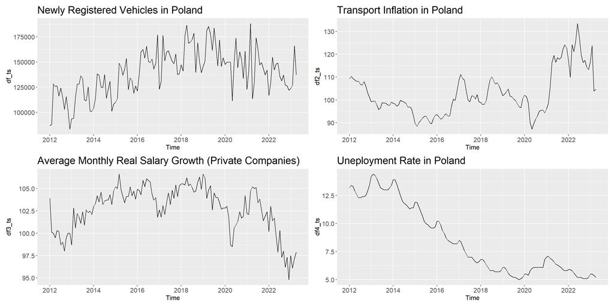

```r
autoplot(df_ts,main="Newly Registered Vehicles in Poland") + th + autoplot(df2_ts,main = "Transport Inflation in Poland") + th +
autoplot(df3_ts,main="Average Monthly Real Salary Growth (Private Companies)") + th +
autoplot(df4_ts,main="Uneployment Rate in Poland") + th
```

#### Merging the data to include all variables in one dataframe

```r
df_merged <- merge(df,df2,by="t")
```

```r
df_merged <- merge(df_merged,df3,by="t")
```

```r
df_merged <- merge(df_merged,df4,by="t")
```

```r
head(df_merged)
```

```
##            t Newly_registered_vehicles transport_inflation
## 1 2012-01-01                     86947               109.2
## 2 2012-02-01                     88000               110.3
## 3 2012-03-01                    128124               109.3
## 4 2012-04-01                    125540               108.7
## 5 2012-05-01                    126435               108.1
## 6 2012-06-01                    116360               108.2
##   Average_monthly_real_gross_salary_business_sector unemployment_rate
## 1                                             103.9              13.2
## 2                                             100.1              13.4
## 3                                             100.0              13.3
## 4                                              99.5              12.9
## 5                                             100.3              12.6
## 6                                             100.2              12.3
```

#### The additional variables are not normally distributed therefore the correlation was measured with the spearman rank correlation

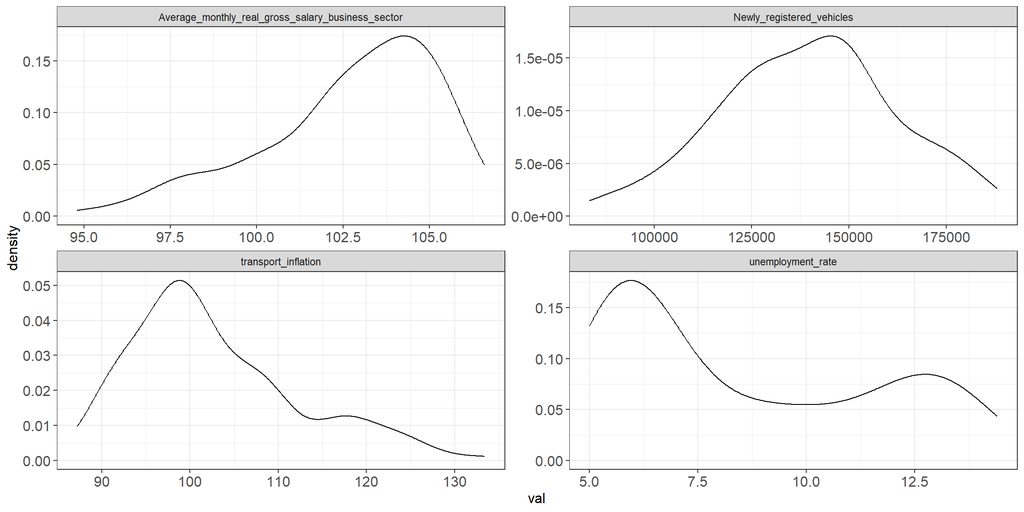

```r
df_merged %>%
gather(c(2:5),key="key",value="val") %>%
ggplot(aes(x=val))+
geom_density()+
facet_wrap(~key,scales="free") +
theme_bw() +
th
```

#### Shapiro wilk test results

```r
shapiro.test(df_merged$Average_monthly_real_gross_salary_business_sector)
```

```
##
##  Shapiro-Wilk normality test
##
## data:  df_merged$Average_monthly_real_gross_salary_business_sector
## W = 0.93525, p-value = 6.329e-06
```

```r
shapiro.test(df_merged$transport_inflation)
```

```
##
##  Shapiro-Wilk normality test
##
## data:  df_merged$transport_inflation
## W = 0.93324, p-value = 4.613e-06
```

```r
shapiro.test(df_merged$unemployment_rate)
```

```
##
##  Shapiro-Wilk normality test
##
## data:  df_merged$unemployment_rate
## W = 0.8586, p-value = 4.469e-10
```

### **5.1 Correlation between newly registered vehicles in Poland and inflation in the transport sector in Poland**

```r
cor(df_merged$Newly_registered_vehicles,df_merged$transport_inflation,method="spearman")
```

```
## [1] 0.04255705
```

### **5.2 Correlation between newly registered vehicles in Poland and average monthly real gross salary in private sector in Poland**

```r
cor(df_merged$Newly_registered_vehicles,df_merged$Average_monthly_real_gross_salary_business_sector,method="spearman")
```

```
## [1] 0.3964819
```

### **5.3 Correlation between newly registered vehicles in Poland and unemployment rate in Poland**

```r
cor(df_merged$Newly_registered_vehicles,df_merged$unemployment_rate,method="spearman")
```

```
## [1] -0.5530952
```

## **5.4 Conclusions regarding correlation**

#### Inflation in the transport sector exhibits almost no influence of the number of newly registered vehicles in Poland. It indicates that Poles don’t pay too much attention to the inflation rate (regarding transport) when it comes to buying new vehicles. Perhaps consumers presume that the vehicles (especially cars) are going to be even more expensive in the future

#### There is a positive correlation between newly registered vehicles in Poland and Average monthly real gross salary in private sector in Poland

#### There is a negative correlation between newly registered vehicles in Poland and the unemployment_rate in Poland

## **6 Proper time series analysis part - newly registered vehicles in Poland**

### **6.1 Stationarity exploration**

#### In order for the time series data to be stationary, it should have:

#### Equal mean (which indicates no trend)

#### Equal variance (which indicates no seasonality)

#### If the time series data was divided into multiple and equal parts, technically it should exhibit very similar distributions

#### Low p-value (lower than alpha) from the ADF (Augmented-Dicker-Fuller) test, where H0 states non-stationarity

#### Based on the ACF plot:

#### The plot exhibits trend and seasonality, because the “spikes” are high at the beginning, and then quickly decrease in a cyclical movement

#### All of the “spikes” are out of the insignificance area which indicates high auto-correlation within the data

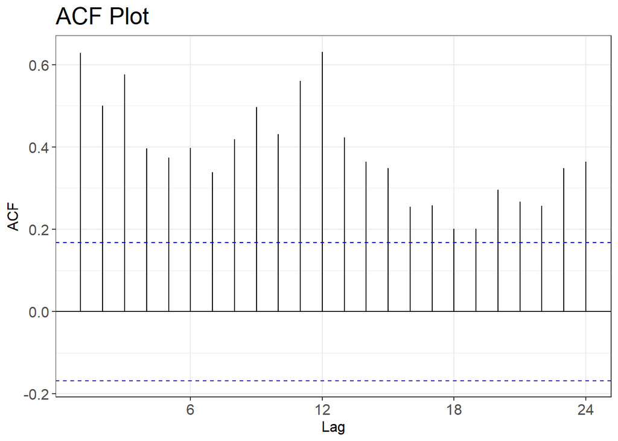

```r
ggAcf(df_ts) + ggtitle("ACF Plot") + theme_bw() + th
```

#### The PACF plot pictures significant correlation between Y at t=0 and Y at t=1,2,3,8,9,11,12,13,14

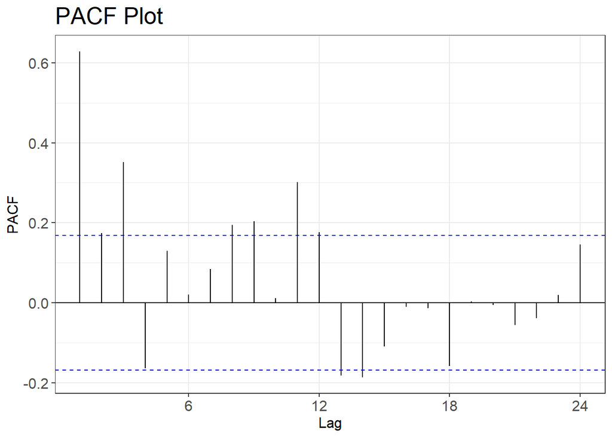

```r
ggPacf(df_ts) + ggtitle("PACF Plot") + theme_bw() + th
```

#### ADF Test:

#### H0: Non-stationary series

#### H1: Stationary series

```r
adf.test(df_ts,k=12)
```

```
##
##  Augmented Dickey-Fuller Test
##
## data:  df_ts
## Dickey-Fuller = -0.011423, Lag order = 12, p-value = 0.99
## alternative hypothesis: stationary
```

#### The data is non-stationary because:

#### It exhibits trend (it’s better pictured with the usage of the time series decomposition below)

#### It exhibits seasonality (it’s better pictured with the usage of the time series decomposition below)

#### It exhibits strong auto-correlation between Yt and its lags

#### The p-value from the ADF test transcends the alpha value (0.05) and therefore there is no proof for rejecting the H0

## **7 Time series decomposition**

#### Based on the decomposition:

#### Data exhibits trend

#### Data exhibits seasonality (every 12 months)

#### What is left after taking the trend and seasonal component appears to be random (mean = 0 and no clear patterns)

```r
fit <- decompose(df_ts)
```

```r
p1 <- autoplot(fit$trend, main = "Trend Component") + theme_bw()
p2 <- autoplot(fit$seasonal, main = "Seasonal Component") + theme_bw()
p3 <- autoplot(fit$random, main ="Random Component" ) + theme_bw()
```

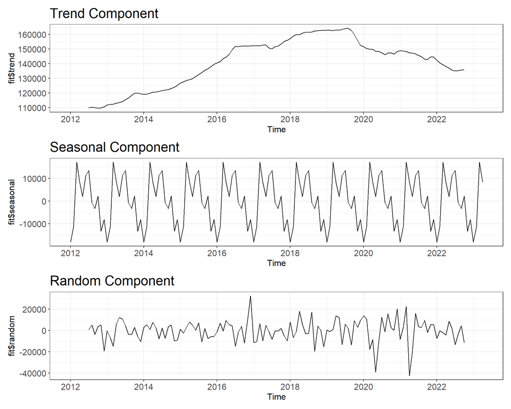

```r
(p1 + th)/(p2 + th)/(p3 + th)
```

## **8 Seasonality exploration**

#### Based on the plot below:

#### There was more newly registered vehicles (on average) in months:

#### March

#### June

#### July

#### There was fewer newly registered vehicles (on average) in months:

#### January

#### February

#### November

#### December

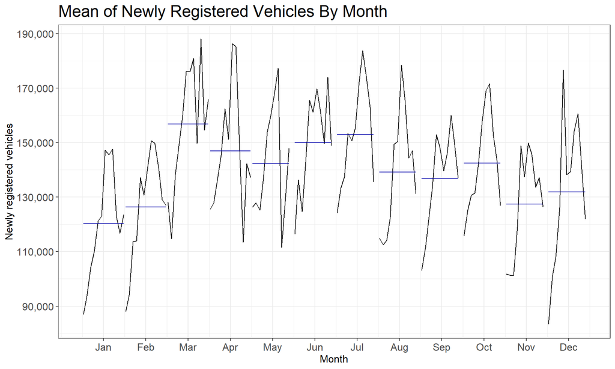

```r
ggsubseriesplot(df_ts,main = "Mean of Newly Registered Vehicles By Month") +
  scale_y_continuous(breaks = seq(70000,190000,20000), labels = comma_format()) + labs(y="Newly registered vehicles",x="Month") + theme_bw() +
  th
```

## **9 The base data, its trend and seasonality in one graph**

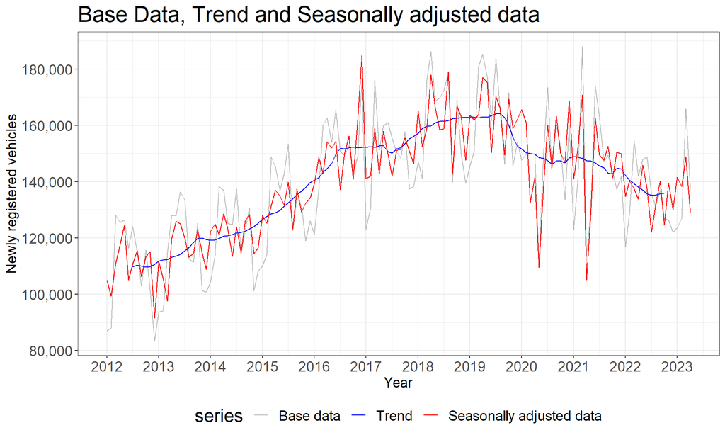

```r
autoplot(df_ts,series="Base data") +
  autolayer(trendcycle(fit), series="Trend") +
  autolayer(seasadj(fit),series="Seasonally adjusted data")+
  scale_y_continuous(breaks = seq(round(min(df_ts),-4),round(max(df_ts),-4),by=20000),
                     labels = comma_format())+
  scale_x_continuous(breaks=seq(min(time(df_ts)),max(time(df_ts))+1,by=1)) +
  scale_colour_manual(values=c("grey","blue","red"),
             breaks=c("Base data","Trend","Seasonally adjusted data"))+
  labs(y="Newly registered vehicles",
       x="Year",
       title="Base Data, Trend and Seasonally adjusted data")+
  theme_bw()+
  theme(legend.position = "bottom",
        axis.text.x = element_text(size=14),
        axis.text.y = element_text(size=14),
        title = element_text(size=18),
        legend.title = element_text(size=18),
        legend.text = element_text(size=14),
        axis.title.x = element_text(size=14),
        axis.title.y = element_text(size=14))
```

## **10 Different forecast methods - prediction from May 2023 to April 2025**

### **10.1 Mean forecast**

#### The Mean method predicts the future based on the mean from the dataset - in this case it’s around 140 000 with expected variation within the confidence interval

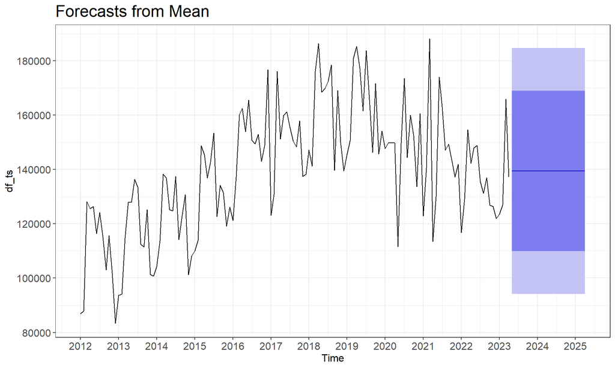

```r
autoplot(meanf(df_ts,h=24)) +
  scale_y_continuous(breaks = seq(round(min(df_ts),-4),round(max(df_ts),-4),by=20000)) +
  scale_x_continuous(breaks = seq(2012,2025,1))+
  theme_bw() +
  th
```

```r
forecast(meanf(df_ts,h=24)) %>%
    kable(align = "c") %>%
    kable_styling(position = "center") %>%
    scroll_box(height = "100%")
```

|  | Point Forecast | Lo 80 | Hi 80 | Lo 95 | Hi 95 |
| --- | --- | --- | --- | --- | --- |
| May 2023 | 139410.3 | 109938.6 | 168882.1 | 94152.1 | 184668.6 |
| Jun 2023 | 139410.3 | 109938.6 | 168882.1 | 94152.1 | 184668.6 |
| Jul 2023 | 139410.3 | 109938.6 | 168882.1 | 94152.1 | 184668.6 |
| Aug 2023 | 139410.3 | 109938.6 | 168882.1 | 94152.1 | 184668.6 |
| Sep 2023 | 139410.3 | 109938.6 | 168882.1 | 94152.1 | 184668.6 |
| Oct 2023 | 139410.3 | 109938.6 | 168882.1 | 94152.1 | 184668.6 |
| Nov 2023 | 139410.3 | 109938.6 | 168882.1 | 94152.1 | 184668.6 |
| Dec 2023 | 139410.3 | 109938.6 | 168882.1 | 94152.1 | 184668.6 |
| Jan 2024 | 139410.3 | 109938.6 | 168882.1 | 94152.1 | 184668.6 |
| Feb 2024 | 139410.3 | 109938.6 | 168882.1 | 94152.1 | 184668.6 |
| Mar 2024 | 139410.3 | 109938.6 | 168882.1 | 94152.1 | 184668.6 |
| Apr 2024 | 139410.3 | 109938.6 | 168882.1 | 94152.1 | 184668.6 |
| May 2024 | 139410.3 | 109938.6 | 168882.1 | 94152.1 | 184668.6 |
| Jun 2024 | 139410.3 | 109938.6 | 168882.1 | 94152.1 | 184668.6 |
| Jul 2024 | 139410.3 | 109938.6 | 168882.1 | 94152.1 | 184668.6 |
| Aug 2024 | 139410.3 | 109938.6 | 168882.1 | 94152.1 | 184668.6 |
| Sep 2024 | 139410.3 | 109938.6 | 168882.1 | 94152.1 | 184668.6 |
| Oct 2024 | 139410.3 | 109938.6 | 168882.1 | 94152.1 | 184668.6 |
| Nov 2024 | 139410.3 | 109938.6 | 168882.1 | 94152.1 | 184668.6 |
| Dec 2024 | 139410.3 | 109938.6 | 168882.1 | 94152.1 | 184668.6 |
| Jan 2025 | 139410.3 | 109938.6 | 168882.1 | 94152.1 | 184668.6 |
| Feb 2025 | 139410.3 | 109938.6 | 168882.1 | 94152.1 | 184668.6 |
| Mar 2025 | 139410.3 | 109938.6 | 168882.1 | 94152.1 | 184668.6 |
| Apr 2025 | 139410.3 | 109938.6 | 168882.1 | 94152.1 | 184668.6 |

### **10.2 Naive forecast**

#### The naive method predicts the future based on the last value from the data set - in this case it’s also around 140 000

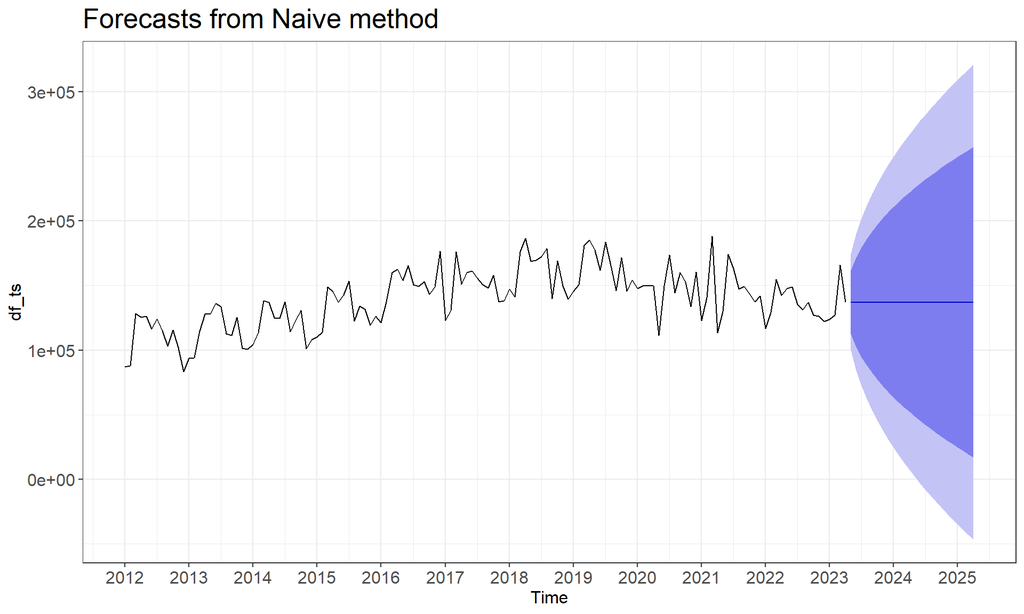

```r
autoplot(naive(df_ts,h=24)) +
  scale_x_continuous(breaks = seq(2012,2025,1))+
  theme_bw() +
  th
```

```r
forecast(naive(df_ts,h=24)) %>%
    kable(align = "c") %>%
    kable_styling(position = "center") %>%
    scroll_box(height = "100%")
```

|  | Point Forecast | Lo 80 | Hi 80 | Lo 95 | Hi 95 |
| --- | --- | --- | --- | --- | --- |
| May 2023 | 137139 | 112631.46 | 161646.5 | 99657.953 | 174620.0 |
| Jun 2023 | 137139 | 102480.11 | 171797.9 | 84132.795 | 190145.2 |
| Jul 2023 | 137139 | 94690.70 | 179587.3 | 72219.922 | 202058.1 |
| Aug 2023 | 137139 | 88123.92 | 186154.1 | 62176.906 | 212101.1 |
| Sep 2023 | 137139 | 82338.48 | 191939.5 | 53328.831 | 220949.2 |
| Oct 2023 | 137139 | 77108.03 | 197170.0 | 45329.560 | 228948.4 |
| Nov 2023 | 137139 | 72298.15 | 201979.9 | 37973.470 | 236304.5 |
| Dec 2023 | 137139 | 67821.21 | 206456.8 | 31126.590 | 243151.4 |
| Jan 2024 | 137139 | 63616.38 | 210661.6 | 24695.859 | 249582.1 |
| Feb 2024 | 137139 | 59639.36 | 214638.6 | 18613.522 | 255664.5 |
| Mar 2024 | 137139 | 55856.69 | 218421.3 | 12828.430 | 261449.6 |
| Apr 2024 | 137139 | 52242.39 | 222035.6 | 7300.844 | 266977.2 |
| May 2024 | 137139 | 48775.81 | 225502.2 | 1999.163 | 272278.8 |
| Jun 2024 | 137139 | 45440.18 | 228837.8 | -3102.237 | 277380.2 |
| Jul 2024 | 137139 | 42221.71 | 232056.3 | -8024.471 | 282302.5 |
| Aug 2024 | 137139 | 39108.84 | 235169.2 | -12785.188 | 287063.2 |
| Sep 2024 | 137139 | 36091.83 | 238186.2 | -17399.316 | 291677.3 |
| Oct 2024 | 137139 | 33162.32 | 241115.7 | -21879.615 | 296157.6 |
| Nov 2024 | 137139 | 30313.11 | 243964.9 | -26237.097 | 300515.1 |
| Dec 2024 | 137139 | 27537.95 | 246740.0 | -30481.338 | 304759.3 |
| Jan 2025 | 137139 | 24831.35 | 249446.7 | -34620.736 | 308898.7 |
| Feb 2025 | 137139 | 22188.45 | 252089.5 | -38662.694 | 312940.7 |
| Mar 2025 | 137139 | 19604.97 | 254673.0 | -42613.787 | 316891.8 |
| Apr 2025 | 137139 | 17077.07 | 257200.9 | -46479.881 | 320757.9 |

### **10.3 Snaive forecast**

#### Snaive method predicts the future based on the last seasonal period (in this case there is a yearly seasonality). Therefore for 2 years prediction, the second year prediction is the same as for the first year**

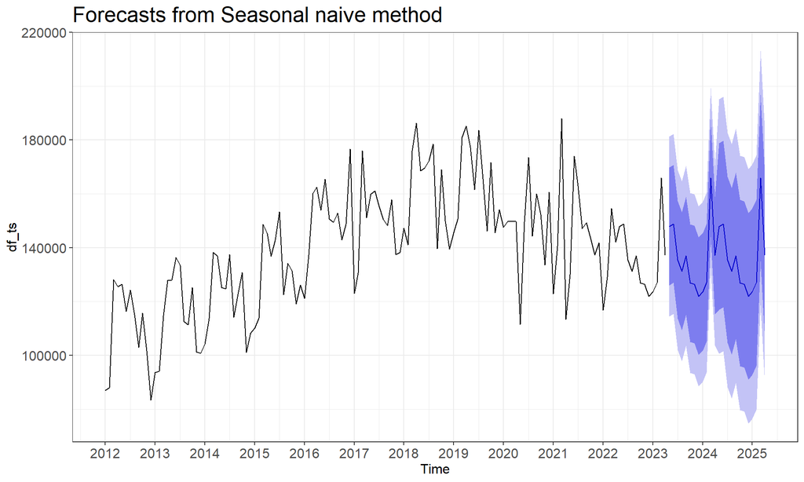

```r
autoplot(snaive(df_ts,h = 24)) +
  scale_x_continuous(breaks = seq(2012,2025,1))+
  theme_bw() +
  th
```

```r
forecast(snaive(df_ts,h=24)) %>%
    kable(align = "c") %>%
    kable_styling(position = "center") %>%
    scroll_box(height = "100%")
```

|  | Point Forecast | Lo 80 | Hi 80 | Lo 95 | Hi 95 |
| --- | --- | --- | --- | --- | --- |
| May 2023 | 147888 | 126033.49 | 169742.5 | 114464.42 | 181311.6 |
| Jun 2023 | 148873 | 127018.49 | 170727.5 | 115449.42 | 182296.6 |
| Jul 2023 | 135515 | 113660.49 | 157369.5 | 102091.42 | 168938.6 |
| Aug 2023 | 131251 | 109396.49 | 153105.5 | 97827.42 | 164674.6 |
| Sep 2023 | 137006 | 115151.49 | 158860.5 | 103582.42 | 170429.6 |
| Oct 2023 | 126879 | 105024.49 | 148733.5 | 93455.42 | 160302.6 |
| Nov 2023 | 126389 | 104534.49 | 148243.5 | 92965.42 | 159812.6 |
| Dec 2023 | 121959 | 100104.49 | 143813.5 | 88535.42 | 155382.6 |
| Jan 2024 | 123610 | 101755.49 | 145464.5 | 90186.42 | 157033.6 |
| Feb 2024 | 127002 | 105147.49 | 148856.5 | 93578.42 | 160425.6 |
| Mar 2024 | 165882 | 144027.49 | 187736.5 | 132458.42 | 199305.6 |
| Apr 2024 | 137139 | 115284.49 | 158993.5 | 103715.42 | 170562.6 |
| May 2024 | 147888 | 116981.06 | 178794.9 | 100619.92 | 195156.1 |
| Jun 2024 | 148873 | 117966.06 | 179779.9 | 101604.92 | 196141.1 |
| Jul 2024 | 135515 | 104608.06 | 166421.9 | 88246.92 | 182783.1 |
| Aug 2024 | 131251 | 100344.06 | 162157.9 | 83982.92 | 178519.1 |
| Sep 2024 | 137006 | 106099.06 | 167912.9 | 89737.92 | 184274.1 |
| Oct 2024 | 126879 | 95972.06 | 157785.9 | 79610.92 | 174147.1 |
| Nov 2024 | 126389 | 95482.06 | 157295.9 | 79120.92 | 173657.1 |
| Dec 2024 | 121959 | 91052.06 | 152865.9 | 74690.92 | 169227.1 |
| Jan 2025 | 123610 | 92703.06 | 154516.9 | 76341.92 | 170878.1 |
| Feb 2025 | 127002 | 96095.06 | 157908.9 | 79733.92 | 174270.1 |
| Mar 2025 | 165882 | 134975.06 | 196788.9 | 118613.92 | 213150.1 |
| Apr 2025 | 137139 | 106232.06 | 168045.9 | 89870.92 | 184407.1 |

### **10.4 Random walk with drift**

#### Random walk with drift is an extension of the trend that occures in the data set. This method implies, that the future data is based on the trend from the past

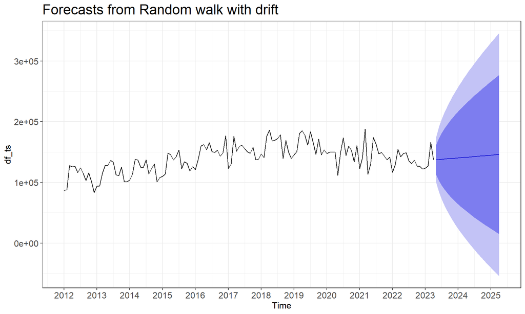

```r
autoplot(rwf(df_ts,h=24,drift=TRUE)) +
  scale_x_continuous(breaks = seq(2012,2025,1))+
  theme_bw() +
  th
```

```r
forecast(rwf(df_ts,h=24)) %>%
    kable(align = "c") %>%
    kable_styling(position = "center") %>%
    scroll_box(height = "100%")
```

[output not shown]

### **10.5 ARIMA**

#### ARIMA is a model that:

#### Uses auto-regression and/or seasonal auto-regression (if needed)

#### Uses differencing to transform the time series from non-stationary to stationary (if needed)

#### Uses moving average (if needed), meaning that it uses residual lags

#### auto.arima function chooses the most optimal model, meaning a model with the lowest AIC score

```r
mod <- auto.arima(df_ts,trace = T)
```

```
##
##  ARIMA(2,1,2)(1,0,1)[12] with drift         : Inf
##  ARIMA(0,1,0)            with drift         : 3048.993
##  ARIMA(1,1,0)(1,0,0)[12] with drift         : 3001.321
##  ARIMA(0,1,1)(0,0,1)[12] with drift         : 2985.264
##  ARIMA(0,1,0)                               : 3046.983
##  ARIMA(0,1,1)            with drift         : 3014.142
##  ARIMA(0,1,1)(1,0,1)[12] with drift         : Inf
##  ARIMA(0,1,1)(0,0,2)[12] with drift         : 2979.204
##  ARIMA(0,1,1)(1,0,2)[12] with drift         : Inf
##  ARIMA(0,1,0)(0,0,2)[12] with drift         : 3026.403
##  ARIMA(1,1,1)(0,0,2)[12] with drift         : 2977.622
##  ARIMA(1,1,1)(0,0,1)[12] with drift         : 2984.325
##  ARIMA(1,1,1)(1,0,2)[12] with drift         : Inf
##  ARIMA(1,1,1)(1,0,1)[12] with drift         : Inf
##  ARIMA(1,1,0)(0,0,2)[12] with drift         : 3004.432
##  ARIMA(2,1,1)(0,0,2)[12] with drift         : 2980.131
##  ARIMA(1,1,2)(0,0,2)[12] with drift         : 2971.916
##  ARIMA(1,1,2)(0,0,1)[12] with drift         : 2979.19
##  ARIMA(1,1,2)(1,0,2)[12] with drift         : Inf
##  ARIMA(1,1,2)(1,0,1)[12] with drift         : Inf
##  ARIMA(0,1,2)(0,0,2)[12] with drift         : 2977.399
##  ARIMA(2,1,2)(0,0,2)[12] with drift         : 2973.978
##  ARIMA(1,1,3)(0,0,2)[12] with drift         : 2974.054
##  ARIMA(0,1,3)(0,0,2)[12] with drift         : 2978.435
##  ARIMA(2,1,3)(0,0,2)[12] with drift         : 2975.101
##  ARIMA(1,1,2)(0,0,2)[12]                    : 2970.017
##  ARIMA(1,1,2)(0,0,1)[12]                    : 2977.408
##  ARIMA(1,1,2)(1,0,2)[12]                    : Inf
##  ARIMA(1,1,2)(1,0,1)[12]                    : Inf
##  ARIMA(0,1,2)(0,0,2)[12]                    : 2975.649
##  ARIMA(1,1,1)(0,0,2)[12]                    : 2975.892
##  ARIMA(2,1,2)(0,0,2)[12]                    : 2972.078
##  ARIMA(1,1,3)(0,0,2)[12]                    : 2972.14
##  ARIMA(0,1,1)(0,0,2)[12]                    : 2977.325
##  ARIMA(0,1,3)(0,0,2)[12]                    : 2976.583
##  ARIMA(2,1,1)(0,0,2)[12]                    : 2978.001
##  ARIMA(2,1,3)(0,0,2)[12]                    : 2973.264
##
##  Best model: ARIMA(1,1,2)(0,0,2)[12]
```

```r
summary(mod)
```

```
## Series: df_ts
## ARIMA(1,1,2)(0,0,2)[12]
##
## Coefficients:
##           ar1     ma1      ma2    sma1    sma2
##       -0.7016  0.0734  -0.7926  0.4466  0.2667
## s.e.   0.1272  0.0936   0.0713  0.0926  0.0854
##
## sigma^2 = 1.92e+08:  log likelihood = -1478.68
## AIC=2969.36   AICc=2970.02   BIC=2986.79
##
## Training set error measures:
##                    ME     RMSE      MAE         MPE     MAPE      MASE
## Training set 917.6767 13548.99 10517.81 -0.06463951 7.607922 0.7974773
##                    ACF1
## Training set 0.01628771
```

#### ARIMA specification and important metrics

#### ARIMA(1,1,2)(0,0,2)[12] indicates:

#### First row of auto-regression

#### First row of differencing (to transform the data to stationary time series)

#### Second row of moving average

#### No seasonal auto-regression

#### No seasonal differencing

#### Second row of seasonal moving average

#### Seasonality occurs every 12 months

#### Important metrics:

#### MAE(mean absolute error)= indicates that the average absolute difference between actual value and its prediction = 10517.81

#### MAPE(mean absolute percentage error) indicates that the model was wrong by 7.61% on average

#### RMSE(root mean squared error) = indicates that the root of the average of squared differences between actual observation and its prediction = 13548.99

#### Formulas:

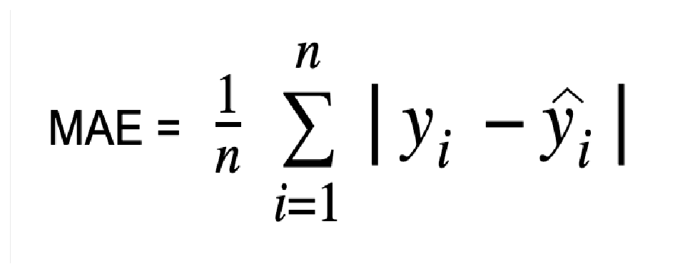

```r
ggplot() +
    background_image(readPNG("images/MAE.png"))
```

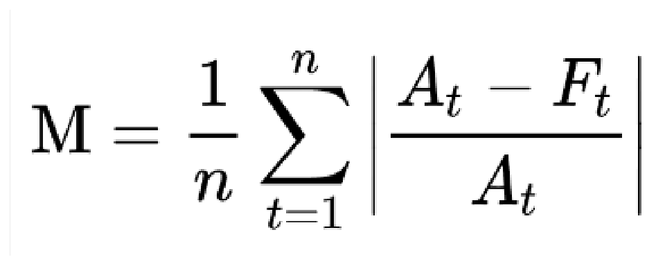

```r
ggplot() +
    background_image(readPNG("images/MAPE.png"))
```

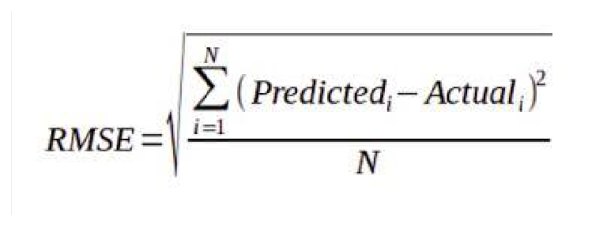

```r
ggplot() +
    background_image(readJPEG("images/rmse.jpg"))
```

#### ARIMA prediction (next 2 years: May 2023 - April 2025)

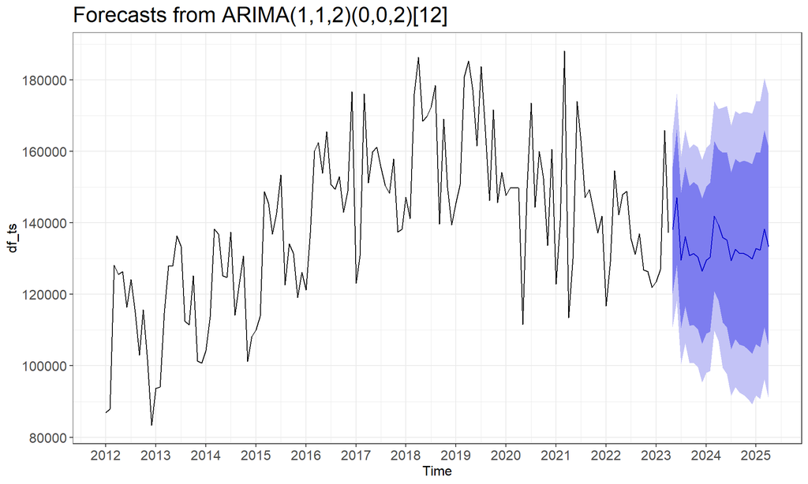

```r
autoplot(forecast(mod,h = 24))+
  scale_y_continuous(breaks = seq(round(min(df_ts),-4),round(max(df_ts),-4),by=20000))+
  scale_x_continuous(breaks = seq(2012,2025, by = 1))+
  theme_bw() +
  th
```

```r
forecast(mod,h=24) %>%
    kable(align = "c") %>%
    kable_styling(position = "center") %>%
    scroll_box(height = "100%")
```

|  | Point Forecast | Lo 80 | Hi 80 | Lo 95 | Hi 95 |
| --- | --- | --- | --- | --- | --- |
| May 2023 | 138027.6 | 120267.7 | 155787.5 | 110866.16 | 165189.1 |
| Jun 2023 | 147110.1 | 128161.9 | 166058.3 | 118131.31 | 176088.9 |
| Jul 2023 | 129558.0 | 110606.5 | 148509.6 | 100574.17 | 158541.9 |
| Aug 2023 | 136150.2 | 116615.0 | 155685.3 | 106273.75 | 166026.6 |
| Sep 2023 | 130795.3 | 111189.5 | 150401.2 | 100810.86 | 160779.8 |
| Oct 2023 | 131439.0 | 111464.3 | 151413.7 | 100890.29 | 161987.7 |
| Nov 2023 | 130421.0 | 110313.4 | 150528.5 | 99669.17 | 161172.8 |
| Dec 2023 | 126501.1 | 106113.2 | 146889.0 | 95320.56 | 157681.7 |
| Jan 2024 | 129513.3 | 108957.3 | 150069.4 | 98075.57 | 160951.1 |
| Feb 2024 | 130333.1 | 109537.5 | 151128.6 | 98529.04 | 162137.1 |
| Mar 2024 | 141850.6 | 120870.0 | 162831.1 | 109763.59 | 173937.6 |
| Apr 2024 | 139433.1 | 118233.8 | 160632.4 | 107011.56 | 171854.6 |
| May 2024 | 135894.6 | 112107.8 | 159681.4 | 99515.85 | 172273.3 |
| Jun 2024 | 135212.1 | 110696.5 | 159727.7 | 97718.68 | 172705.5 |
| Jul 2024 | 129387.1 | 104682.1 | 154092.1 | 91604.06 | 167170.2 |
| Aug 2024 | 132666.2 | 107445.6 | 157886.9 | 94094.58 | 171237.9 |
| Sep 2024 | 131473.7 | 105989.5 | 156958.0 | 92498.93 | 170448.6 |
| Oct 2024 | 131479.1 | 105574.0 | 157384.3 | 91860.63 | 171097.7 |
| Nov 2024 | 130865.2 | 104660.2 | 157070.3 | 90788.14 | 170942.4 |
| Dec 2024 | 129925.5 | 103346.6 | 156504.4 | 89276.57 | 170574.4 |
| Jan 2025 | 132891.1 | 105997.9 | 159784.2 | 91761.56 | 174020.5 |
| Feb 2025 | 132413.4 | 105172.4 | 159654.5 | 90751.80 | 174075.0 |
| Mar 2025 | 138305.6 | 110747.1 | 165864.1 | 96158.47 | 180452.7 |
| Apr 2025 | 133373.5 | 105483.1 | 161263.9 | 90718.88 | 176028.1 |

#### ARIMA residuals

#### The residuals appear to be randomly distributed. Ljung-box test results (p-value = 0.08817) indicates that the residuals are random, although 2 spikes from the ACF plot excess the insignifance area

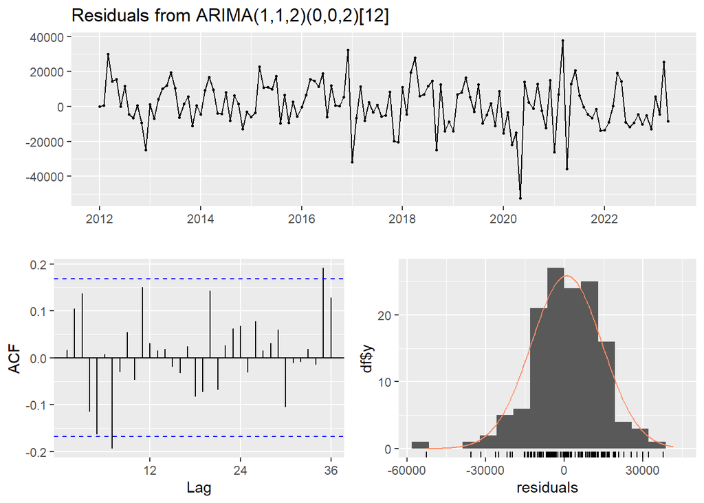

```
##
##  Ljung-Box test
##
## data:  Residuals from ARIMA(1,1,2)(0,0,2)[12]
## Q* = 27.76, df = 19, p-value = 0.08817
##
## Model df: 5.   Total lags used: 24
```

```r
checkresiduals(mod)
```

#### Visualizing all prediction methods at once

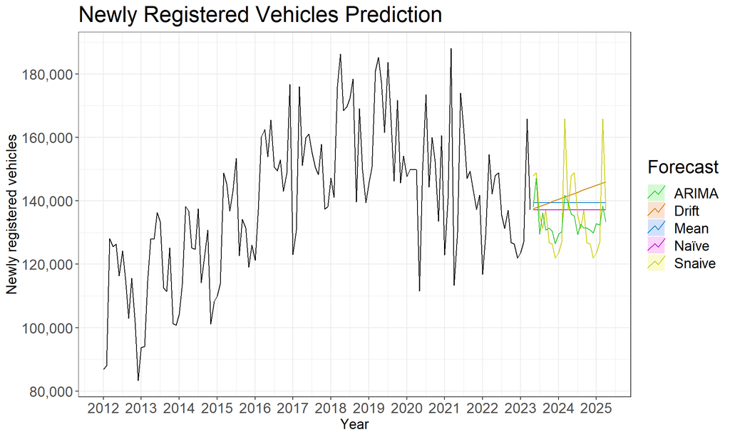

```r
autoplot(df_ts) +
  autolayer(meanf(df_ts, h=24),
    series="Mean", PI=FALSE) +
  autolayer(naive(df_ts, h=24),
    series="Naïve", PI=FALSE) +
  autolayer(rwf(df_ts, drift=TRUE, h=24),
    series="Drift", PI=FALSE) +
  autolayer(snaive(df_ts,h = 24),
    series="Snaive", PI = FALSE) +
  autolayer(forecast(mod,h = 24,level = FALSE),
    series="ARIMA",PI = FALSE) +
  ggtitle("Newly Registered Vehicles Prediction") +
  xlab("Year") + ylab("Newly registered vehicles") +
  guides(colour=guide_legend(title="Forecast")) +
  scale_color_manual(values=c("#1BF31B","#FE5E02","#025AFE","#FB02FE","#FAFE02")) +
  scale_x_continuous(breaks=seq(min(time(df_ts)),max(time(df_ts)+3)))+
  scale_y_continuous(breaks=seq(round(min(df_ts),-4),round(max(df_ts),-4),by=20000),labels=comma_format())+
  theme_bw()+
  theme(axis.text.x = element_text(size=14),
        axis.text.y = element_text(size=14),
        legend.title = element_text(size=18),
        legend.text = element_text(size=14),
        title = element_text(size=18),
        axis.title.x = element_text(size=14),
        axis.title.y = element_text(size=14))
```

## **10 Sources**

1. [Vehicle classification] http://www.cepik.gov.pl/documents/76251/76577/Pojazdy+zarejestrowane+w+2022+r.+rodzajami+I-X+%28pdf%29/e35a777f-f2a1-472d-b3ae-9162f022543d
2. [2022 data] http://www.cepik.gov.pl/documents/76251/76577/Pojazdy+zarejestrowane+w+2022+r.+województwami+I-X+%28pdf%29/bc07beef-ae6c-41a7-acb3-49ff301ac6a8
3. [2021 data] http://www.cepik.gov.pl/documents/76251/76577/Pojazdy+zarejestrowane+w+2021+r.+województwami+I-XII+%28pdf%29/f04cf159-3611-4c61-b725-2d7fdf02f711
4. [2020 data] http://www.cepik.gov.pl/documents/76251/76577/Pojazdy+zarejestrowane+w+2020+r.+województwami+%28pdf%29+I-XII/12b09706-5453-4ce2-b941-2b00ff4ae8d2
5. [2019 data] http://www.cepik.gov.pl/documents/76251/76577/Pojazdy+zarejestrowane+w+2019+r.+województwami+%28pdf%29/4663a082-1e19-4cfd-aea1-f0d34e1f75b0
6. [2018 data] http://www.cepik.gov.pl/documents/76251/76577/Pojazdy+zarejestrowane+w+2018+r.+województwami+%28pdf%29/bcedb4a2-8256-47bd-bfbf-644e704d0fe2
7. [2017 data] http://www.cepik.gov.pl/documents/76251/76577/Pojazdy+zarejestrowane+w+2017+r.+województwami/ceb7ade4-db2f-43da-a8a3-a41683fe08bd
8. [2016 data] http://www.cepik.gov.pl/documents/76251/76577/Pojazdy+wg+województw+z+grudniem+2016/c5771bd3-4f24-4d90-8797-eed815d1fe8e
9. [2015 data] http://www.cepik.gov.pl/documents/76251/76577/Zarejestrowane+pojazdy+wg+województw+z+grudniem/7aae6743-c578-47ac-a2a8-8aabad6cdae7
10. [2014 data] http://www.cepik.gov.pl/documents/76251/76577/Pojazdy+zarejestrowane+2014/2c43af63-0f36-4c94-bc47-1605b7840796
11. [2013 data] http://www.cepik.gov.pl/documents/76251/76577/Pojazdy+zarejestrowane+w+2013+r/d66dcbf6-f2ce-4f94-96f6-7d9976c418e3 [2012 data] http://www.cepik.gov.pl/documents/76251/76577/Pojazdy+zarejestrowane+w+2012+r/9b58921a-8131-4830-a4c1-9b65955e1bde